# Pracitcal Machine Learning Project

charzee

5/31/2021

## Project Goal

One thing that people regularly do is quantify how much of a particular activity they do, but they rarely quantify how well they do it. In this project, your goal will be to use data from accelerometers on the belt, forearm, arm, and dumbell of 6 participants.

The goal of your project is to predict the manner in which they did the exercise. This is the “classe” variable in the training set. You may use any of the other variables to predict with. You should create a report describing how you built your model, how you used cross validation, what you think the expected out of sample error is, and why you made the choices you did. You will also use your prediction model to predict 20 different test cases.

## Project Summary

Below I:

- Load data
- Clean/Treat it
- Train it
- Run through four models
- Find the model with the most accuracy
- Use the most accurate model to predict the activity quality

## Load Libraries and Data

```r
#Load Libraries
library(lattice)
library(ggplot2)
library(caret)
library(kernlab)
library(rattle)
library(corrplot)
set.seed(1234)

#Load Data
df.train <- read.csv("datasets/pml-training.csv") #load training data
df.test <- read.csv("datasets/pml-testing.csv") #load test data
```

## Prep and Clean Data

```r
#Clean Data

#remove NA and metatdata
df.train <- df.train[,colMeans(is.na(df.train)) < .9] #remove data that's mostly NA
df.train <- df.train[,-c(1:7)] #remove first 7 columns that contain metadata

#remove columns with little variance in values
zero.var <- nearZeroVar(df.train)
df.train <- df.train[,-zero.var]

#split into a validation and training set
df.sample <- createDataPartition(y=df.train$classe, p=0.7, list=F)
train.set <- df.train[df.sample,]
validation.set <- df.train[-df.sample,]
```

## Create Models and Review Confusion Matrix for Accuracy

```r
tc <- trainControl(method="cv", number=3, verboseIter = F) #train control
```

### Decision Tree Model

```r
# Decision Tree Model
model.decision.tree <- train(classe~., data=train.set, method="rpart", trControl = tc, tuneLength = 5)

# Decision Tree Prediction
predict.decision.tree <- predict(model.decision.tree, validation.set)
confusion.matrix.decision.trees <- confusionMatrix(predict.decision.tree, factor(validation.set$classe))  #confusion matrix
confusion.matrix.decision.trees
```

```
## Confusion Matrix and Statistics
##
##           Reference
## Prediction    A    B    C    D    E
##          A 1519  473  484  451  156
##          B   28  355   45   10  130
##          C   83  117  423  131  131
##          D   40  194   74  372  176
##          E    4    0    0    0  489
##
## Overall Statistics
##
##                Accuracy : 0.5366
##                  95% CI : (0.5238, 0.5494)
##     No Information Rate : 0.2845
##     P-Value [Acc > NIR] : < 2.2e-16
##
##                   Kappa : 0.3957
##
##  Mcnemar's Test P-Value : < 2.2e-16
##
## Statistics by Class:
##
##                      Class: A Class: B Class: C Class: D Class: E
## Sensitivity            0.9074  0.31168  0.41228  0.38589  0.45194
## Specificity            0.6286  0.95512  0.90492  0.90165  0.99917
## Pos Pred Value         0.4927  0.62500  0.47797  0.43458  0.99189
## Neg Pred Value         0.9447  0.85255  0.87940  0.88228  0.89002
## Prevalence             0.2845  0.19354  0.17434  0.16381  0.18386
## Detection Rate         0.2581  0.06032  0.07188  0.06321  0.08309
## Detection Prevalence   0.5239  0.09652  0.15038  0.14545  0.08377
## Balanced Accuracy      0.7680  0.63340  0.65860  0.64377  0.72555
```

### Random Forest Model

```r
#Random Forest Model
model.random.forest <- train(classe ~., data=train.set, method="rf", trControl = tc)

#Random Forest Prediction
predict.random.forest <- predict(model.random.forest, validation.set)
confusion.matrix.random.forest <- confusionMatrix(predict.random.forest, factor(validation.set$classe))
confusion.matrix.random.forest
```

```
## Confusion Matrix and Statistics
##
##           Reference
## Prediction    A    B    C    D    E
##          A 1672    5    0    0    0
##          B    1 1129   15    0    0
##          C    1    5 1009    9    0
##          D    0    0    2  954    0
##          E    0    0    0    1 1082
##
## Overall Statistics
##
##                Accuracy : 0.9934
##                  95% CI : (0.991, 0.9953)
##     No Information Rate : 0.2845
##     P-Value [Acc > NIR] : < 2.2e-16
##
##                   Kappa : 0.9916
##
##  Mcnemar's Test P-Value : NA
##
## Statistics by Class:
##
##                      Class: A Class: B Class: C Class: D Class: E
## Sensitivity            0.9988   0.9912   0.9834   0.9896   1.0000
## Specificity            0.9988   0.9966   0.9969   0.9996   0.9998
## Pos Pred Value         0.9970   0.9860   0.9854   0.9979   0.9991
## Neg Pred Value         0.9995   0.9979   0.9965   0.9980   1.0000
## Prevalence             0.2845   0.1935   0.1743   0.1638   0.1839
## Detection Rate         0.2841   0.1918   0.1715   0.1621   0.1839
## Detection Prevalence   0.2850   0.1946   0.1740   0.1624   0.1840
## Balanced Accuracy      0.9988   0.9939   0.9902   0.9946   0.9999
```

### Gradient Boosted Tree

```r
#Gradient Boosted Tree Model
model.gbm <- train(classe~., data = train.set, method="gbm", trControl = tc, tuneLength = 5, verbose = F)

#Gradient Boosted Tree Prediction
predict.gbm <- predict(model.gbm, validation.set)
confusion.matrix.gbm <- confusionMatrix(predict.gbm, factor(validation.set$classe))
confusion.matrix.gbm
```

```
## Confusion Matrix and Statistics
##
##           Reference
## Prediction    A    B    C    D    E
##          A 1670    6    0    0    0
##          B    1 1126   13    1    0
##          C    3    7 1010    9    2
##          D    0    0    3  951    1
##          E    0    0    0    3 1079
##
## Overall Statistics
##
##                Accuracy : 0.9917
##                  95% CI : (0.989, 0.9938)
##     No Information Rate : 0.2845
##     P-Value [Acc > NIR] : < 2.2e-16
##
##                   Kappa : 0.9895
##
##  Mcnemar's Test P-Value : NA
##
## Statistics by Class:
##
##                      Class: A Class: B Class: C Class: D Class: E
## Sensitivity            0.9976   0.9886   0.9844   0.9865   0.9972
## Specificity            0.9986   0.9968   0.9957   0.9992   0.9994
## Pos Pred Value         0.9964   0.9869   0.9796   0.9958   0.9972
## Neg Pred Value         0.9990   0.9973   0.9967   0.9974   0.9994
## Prevalence             0.2845   0.1935   0.1743   0.1638   0.1839
## Detection Rate         0.2838   0.1913   0.1716   0.1616   0.1833
## Detection Prevalence   0.2848   0.1939   0.1752   0.1623   0.1839
## Balanced Accuracy      0.9981   0.9927   0.9900   0.9929   0.9983
```

### Support Vector Machine

```r
#Support Vector Machine Model
model.svm <- train(classe~., data= train.set, method="svmLinear", trControl = tc, tuneLength = 5, verbose = F)

#Support Vector Machine Prediction
predict.svm <- predict(model.svm, validation.set)
confusion.matrix.svm <- confusionMatrix(predict.svm, factor(validation.set$classe))
confusion.matrix.svm
```

```
## Confusion Matrix and Statistics
##
##           Reference
## Prediction    A    B    C    D    E
##          A 1537  154   79   69   50
##          B   29  806   90   46  152
##          C   40   81  797  114   69
##          D   61   22   32  697   50
##          E    7   76   28   38  761
##
## Overall Statistics
##
##                Accuracy : 0.7813
##                  95% CI : (0.7705, 0.7918)
##     No Information Rate : 0.2845
##     P-Value [Acc > NIR] : < 2.2e-16
##
##                   Kappa : 0.722
##
##  Mcnemar's Test P-Value : < 2.2e-16
##
## Statistics by Class:
##
##                      Class: A Class: B Class: C Class: D Class: E
## Sensitivity            0.9182   0.7076   0.7768   0.7230   0.7033
## Specificity            0.9164   0.9332   0.9374   0.9665   0.9690
## Pos Pred Value         0.8137   0.7177   0.7239   0.8086   0.8363
## Neg Pred Value         0.9657   0.9301   0.9521   0.9468   0.9355
## Prevalence             0.2845   0.1935   0.1743   0.1638   0.1839
## Detection Rate         0.2612   0.1370   0.1354   0.1184   0.1293
## Detection Prevalence   0.3210   0.1908   0.1871   0.1465   0.1546
## Balanced Accuracy      0.9173   0.8204   0.8571   0.8447   0.8362
```

## Model Comparison

```r
#Accuracy
models <- c("Decision Tree Model", "Random Forest", "Gradient Boosted Tree (GBM)", "Support Vector Machine (SVM)")
accuracy <- c(round(confusion.matrix.decision.trees$overall[[1]], 3),
              round(confusion.matrix.random.forest$overall[[1]], 3),
              round(confusion.matrix.gbm$overall[[1]], 3),
              round(confusion.matrix.svm$overall[[1]], 3))
df.accuracy <- data.frame(models, accuracy)
df.accuracy
```

```
##                         models accuracy
## 1          Decision Tree Model    0.537
## 2                Random Forest    0.993
## 3  Gradient Boosted Tree (GBM)    0.992
## 4 Support Vector Machine (SVM)    0.781
```

Random Forest has the highest accuracy with 0.993. We’ll use that to predict on the test set.

## Predict

```r
#Predictions on Test Set
df.predict <- predict(model.random.forest, df.test)
df.predict
```

```
##  [1] B A B A A E D B A A B C B A E E A B B B
## Levels: A B C D E
```

## Appendix

Decision Tree Plot

[figure not shown]

```r
fancyRpartPlot(model.decision.tree$finalModel)
```

Model plots:

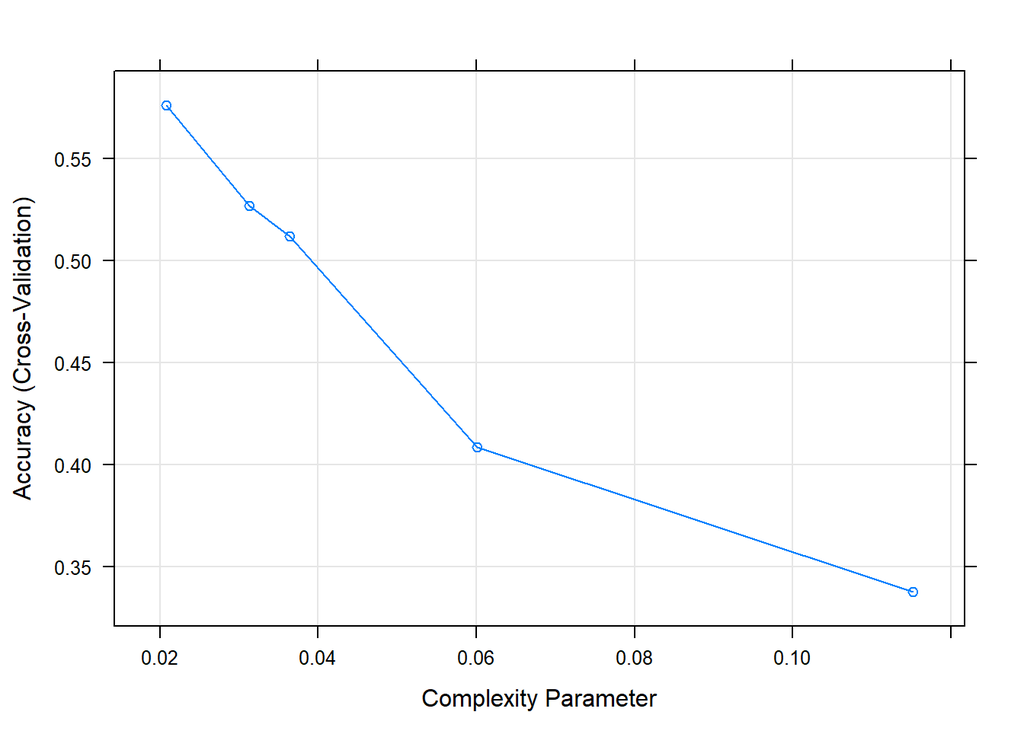

```r
plot(model.decision.tree) #decision tree plot
```

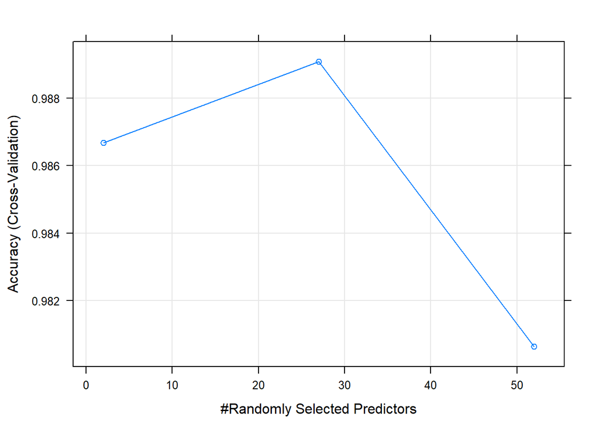

```r
plot(model.random.forest) #random forest plot
```

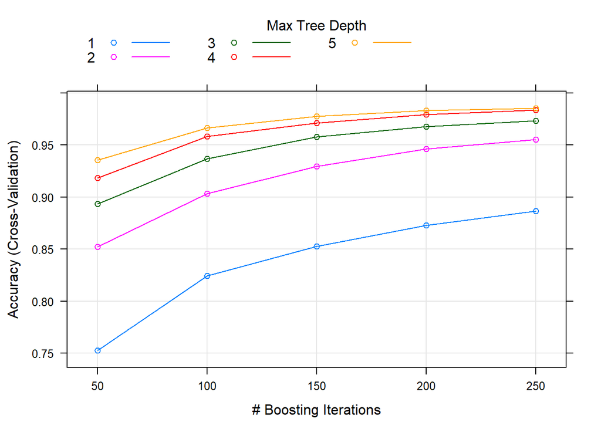

```r
plot(model.gbm) #gbm plot
```